# Class Assignment #01

Yitong Wu

January 26, 2020

Scenario #1: SEX = 1, RACE = 1, MAR = 1

1. If you know someone with SEX = 1, RACE = 1, MAR = 1 and this person is in this sample, can you find out which record in the sample belongs to this person? What additional information can you learn about this person?

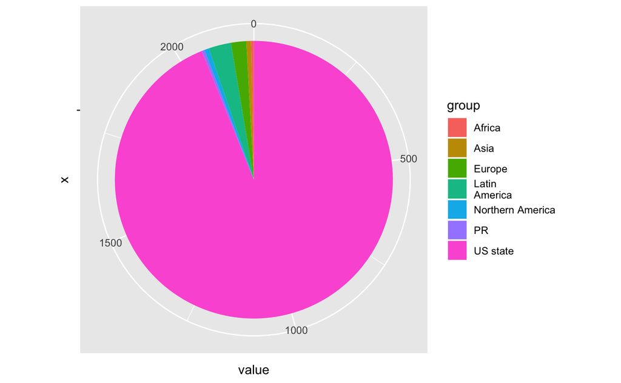

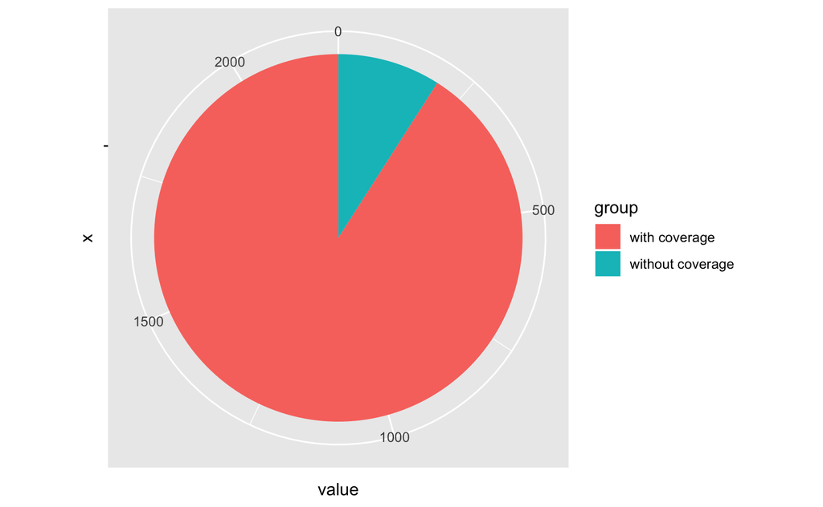

```r
HICOV_data <- c()
for (i in 1:2){
  HICOV_data[i] <- sum(data$HICOV==i)
}
lbls <- c("with coverage", "without coverage")
df <- data.frame(
  group = lbls,
  value = HICOV_data
  )
ggplot(df, aes(x="", y=value, fill=group))+ geom_bar(width = 1, stat = "identity")+ coord_polar("y", start=0)
```

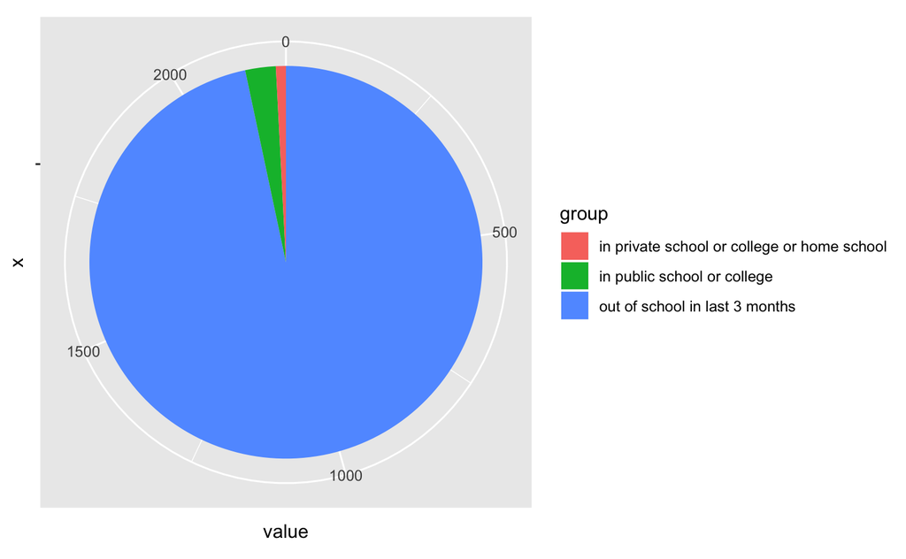

```r
SCH_data <- c()
for (i in 1:3){
  SCH_data[i] <- sum(data$SCH==i)
}
lbls <- c("out of school in last 3 months", "in public school or college", "in private school or college or home school")
df <- data.frame(
  group = lbls,
  value = SCH_data
  )
ggplot(df, aes(x="", y=value, fill=group))+ geom_bar(width = 1, stat = "identity")+ coord_polar("y", start=0)
```

2. If you know someone with SEX = 1, RACE = 1, MAR = 1 but you are not sure if this person is in this sample, what would you do to find this person? What additional information can you learn about this person? Use filter to see if any record in this sample matches the criteria

Scenario #2: SEX = 1, RACE = 1, MAR = 1 and DIS = 1

1. If you know someone with SEX = 1, RACE = 1, MAR = 1, DIS = 1 and this person is in this sample, can you find out which record in the sample belongs to this person? What additional information can you learn about this person?

```r
data <- read.csv("ACSdata.csv")
data <- data %>% filter(SEX = 1, RACE = 1, MAR = 1, DIS = 1)
```

```
错误: `SEX` (`SEX = 1`), `RACE` (`RACE = 1`), `MAR` (`MAR = 1`), `DIS` (`DIS = 1`) must not be named, do you need `==`?
```

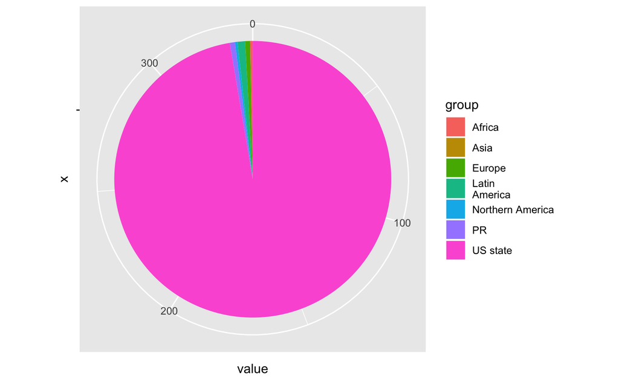

```r
WAOB_data <- c()
for (i in 1:7){
  WAOB_data[i] <- sum(data$WAOB==i)
}
lbls <- c("US state", "PR", "Latin
America", "Asia", "Europe", "Africa", "Northern America")
df <- data.frame(
  group = lbls,
  value = WAOB_data
  )
ggplot(df, aes(x="", y=value, fill=group))+ geom_bar(width = 1, stat = "identity")+ coord_polar("y", start=0)
```

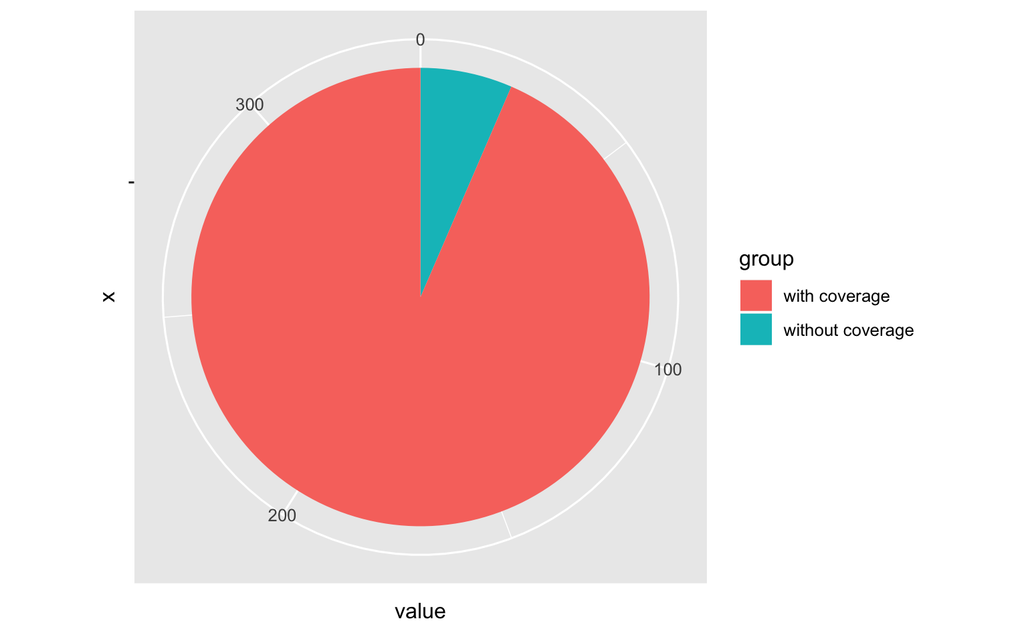

```r
HICOV_data <- c()
for (i in 1:2){
  HICOV_data[i] <- sum(data$HICOV==i)
}
lbls <- c("with coverage", "without coverage")
df <- data.frame(
  group = lbls,
  value = HICOV_data
  )
ggplot(df, aes(x="", y=value, fill=group))+ geom_bar(width = 1, stat = "identity")+ coord_polar("y", start=0)
```

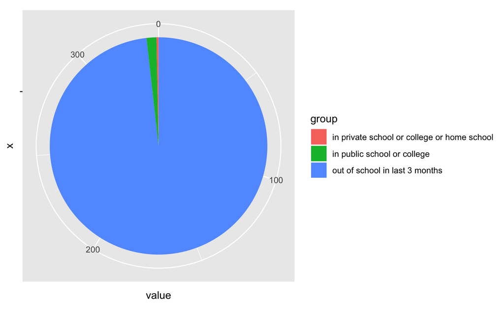

```r
SCH_data <- c()
for (i in 1:3){
  SCH_data[i] <- sum(data$SCH==i)
}
lbls <- c("out of school in last 3 months", "in public school or college", "in private school or college or home school")
df <- data.frame(
  group = lbls,
  value = SCH_data
  )
ggplot(df, aes(x="", y=value, fill=group))+ geom_bar(width = 1, stat = "identity")+ coord_polar("y", start=0)
```

2. Which scenario is more favorable to an intruder, Scenario #1 vs Scenario #2? Scenario #2